# Employee Attrition Study

Steve Bramhall, Hayley Horn

December 7, 2018

#### Abstract

Employees are valuable assets of an organization, and the unexpected departure of a key employee can be disruptive and costly. Our objective with this study is to identify factors that lead to employee attrition, enabling management to establish areas of focus to reduce employee churn.

Turnover is an expensive problem, both in terms of money and time so our data science team is both excited and well positioned to provide our clients with new insights to mitigate employee churn and its associated costs. https://www.forbes.com/sites/billconerly/2018/08/12/companies-need-to-know-the-dollar-cost-of-employee-turnover/#591dbffd590a

Here is information about how we used the data to build a employee attrition model.

#### Data Input

The training and validation data sets were read into data frames. We combined the data frames to one data frame to clean all the data at the same time if needed.

```r
# Read employee data from the training csv file and name the dataset train.
train <- read.csv(".\\InputFiles\\CaseStudy2-data.csv",header=TRUE,stringsAsFactors = TRUE,sep=",",encoding = "UTF-8")

# Read employee data from the validation csv file and names the dataset train.
validation <- read.csv(".\\InputFiles\\CaseStudy2Validation.csv",header=TRUE,stringsAsFactors = TRUE,sep=",",encoding = "UTF-8")

alldata = rbind(train,validation) # create dataframe with all data to clean all at same time
```

#### Data Exploration

The following initial assessments/actions were completed:  
- Reviewed the data to confirm factor/categorical variable values exist in both.  
- Removed variables where all values are the same: StandardHours, EmployeeCount, Over18  
- Removed unrelated variable Rand  
- Recoded Attrition to 0=No, 1=Yes

We classified the variables into 4 areas:

- Demographics: Age, Gender, Marital Status, Education, Education Level and Distance from home (commute)
- Attitudinal: Environmental Satisfaction, Job Satisfaction, Relationship Satisfaction, WorkLifeBalance,Job Involvement, Performance Rating
- Work Demographics: Job ROle, Job Level, Business Travel, Department, Training
- Financial: Hourly Rate (rates are collinear so showing only hourly rate), Overtime, Percent Salary Hike, Stock Option Levels

This document shows the process behind our analysis.

```r
# Mutate for EDA

plotalldata <- alldata %>% mutate(
Age = as.factor
(ifelse(Age %in% 0:21,"Gen Z", ifelse(Age %in% 22:37,"Millenial",
ifelse(Age %in% 38:53,"Gex X", ifelse(Age %in% 54:72,"Boomers",
                                      "Silent"))))),
#Generation Cutoff Ref:
#http://www.pewresearch.org/fact-tank/2018/03/01/defining-generations-where-millennials-end-and-post-millennials-begin/

DistanceFromHome = as.factor
(ifelse(DistanceFromHome %in% 0:2,"<= 2 miles", ifelse(DistanceFromHome %in% 3:5,"3-5 miles",
 ifelse(DistanceFromHome %in% 6:10,"6-9 miles", ifelse(DistanceFromHome  %in% 10:15,"10-15 miles",
">= 16 miles"))))),

Education = as.factor                                                            #Source lastresearch project, best estimate of values
(ifelse(Education == 1,"HS Grad", ifelse(Education == 2, "Some College",
ifelse(Education == 3, "College Grad", ifelse(Education == 4, "Some Post Grad",
"Post Grad"))))),

EnvironmentSatisfaction = as.factor                                              #4 point Likert, best estimate of values
(ifelse(EnvironmentSatisfaction == 1, "Low",ifelse(EnvironmentSatisfaction == 2, "Med",
ifelse(EnvironmentSatisfaction == 3, "High", "Very High")))),

JobInvolvement = as.factor                                                       #4 point Likert, best estimate of values
(ifelse(JobInvolvement == 1, "Low",ifelse(JobInvolvement == 2, "Med",
ifelse(JobInvolvement == 3, "High","Very High")))),

JobLevel = as.factor                                                             #5 point Scale estimate of values
(ifelse(JobLevel == 1, "Contributor",ifelse(JobLevel == 2, "Supervisor",
ifelse(JobLevel == 3, "Manager",ifelse(JobLevel == 4, "Director",
"Co Leadership"))))),

JobSatisfaction = as.factor                                                      #4 point Likert, best estimate of values
(ifelse(JobSatisfaction == 1, "Low",ifelse(JobSatisfaction == 2, "Med",
ifelse(JobSatisfaction == 3, "High","Very High")))),

PerformanceRating = as.factor                                                    #4 point Likert, best estimate of values
(ifelse(PerformanceRating == 1, "Low",ifelse(PerformanceRating == 2, "Med",
ifelse(PerformanceRating == 3, "High", "Very High")))),

RelationshipSatisfaction = as.factor                                             #4 point Likert, best estimate of values
(ifelse(RelationshipSatisfaction == 1, "Low",ifelse(RelationshipSatisfaction == 2, "Med",
ifelse(RelationshipSatisfaction == 3, "High", "Very High")))),

WorkLifeBalance = as.factor                                                      #4 point Likert, best estimate of values
(ifelse(WorkLifeBalance == 1, "Low",ifelse(WorkLifeBalance == 2, "Med",
ifelse(WorkLifeBalance == 3, "High", "Very High"))))
)
```

In the demographic data, it is as expected

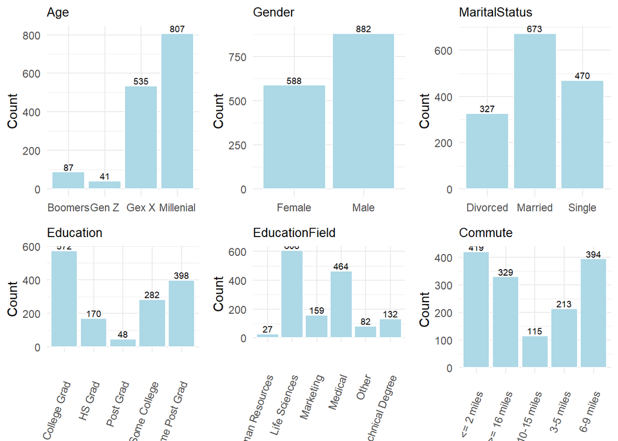

```r
#Demographics

#Plot Counts for High Level View
#Demographics: Age, Gender, Marital Status, Education, Education Level and Distance from home (commute)

AgePlot <- plotalldata %>% group_by(Age) %>%  summarise(counts = n()) %>%
  ggplot(aes(x = as.factor(Age), y = counts)) +
  geom_bar(stat = 'identity', fill = "light blue",col = "white") +
  ggtitle("Age") + ylab("Count") + theme_minimal() +
  geom_text(aes(label=counts), size = 2.5, position=position_dodge(width=0.3), vjust=-0.25) +
  theme(plot.title = element_text(size =10),axis.title.x=element_blank())

GenderPlot <- plotalldata %>%   group_by(Gender) %>%  summarise(counts = n()) %>%
  ggplot(aes(x = as.factor(Gender), y = counts)) +
  geom_bar(stat = 'identity', fill = "light blue",col = "white") +
  ggtitle("Gender") + ylab("Count") + theme_minimal() +
  geom_text(aes(label=counts), size = 2.5, position=position_dodge(width=0.3), vjust=-0.25) +
  theme(plot.title = element_text(size =10),axis.title.x=element_blank())

MaritalStatusPlot <- plotalldata %>%   group_by(MaritalStatus) %>%  summarise(counts = n()) %>%
  ggplot(aes(x = as.factor(MaritalStatus), y = counts)) +
  geom_bar(stat = 'identity', fill = "light blue",col = "white") +
  ggtitle("MaritalStatus") + ylab("Count") + theme_minimal() +
  geom_text(aes(label=counts), size = 2.5, position=position_dodge(width=0.3), vjust=-0.25) +
  theme(plot.title = element_text(size =10),axis.title.x=element_blank())

EducationPlot <- plotalldata %>% group_by(Education) %>%  summarise(counts = n()) %>%
  ggplot(aes(x = as.factor(Education), y = counts)) +
  geom_bar(stat = 'identity', fill = "light blue",col = "white") +
  ggtitle("Education") + ylab("Count") + theme_minimal() +
  geom_text(aes(label=counts), size = 2.5, position=position_dodge(width=0.3), vjust=-0.25) +
  theme(plot.title = element_text(size =10),axis.title.x=element_blank()) +
  theme(axis.text.x=element_text(angle=70,vjust=.7,hjust=1))

EducationFieldPlot <- plotalldata %>%   group_by(EducationField) %>%  summarise(counts = n()) %>%
  ggplot(aes(x = as.factor(EducationField), y = counts)) +
  geom_bar(stat = 'identity', fill = "light blue",col = "white") +
  ggtitle("EducationField") + ylab("Count") + theme_minimal() +
  geom_text(aes(label=counts), size = 2.5, position=position_dodge(width=0.3), vjust=-0.25) +
  theme(plot.title = element_text(size =10),axis.title.x=element_blank()) +
  theme(axis.text.x=element_text(angle=70,vjust=.7,hjust=1))

CommutePlot <- plotalldata %>%   group_by(DistanceFromHome) %>%  summarise(counts = n()) %>%
  ggplot(aes(x = as.factor(DistanceFromHome), y = counts)) +
  geom_bar(stat = 'identity', fill = "light blue",col = "white") +
  ggtitle("Commute") + ylab("Count") + theme_minimal() +
  geom_text(aes(label=counts), size = 2.5, position=position_dodge(width=0.3), vjust=-0.25) +
  theme(plot.title = element_text(size =10),axis.title.x=element_blank()) +
  theme(axis.text.x=element_text(angle=70,vjust=.8,hjust=1))

grid.arrange(AgePlot, GenderPlot, MaritalStatusPlot, EducationPlot, EducationFieldPlot,CommutePlot, nrow = 2, ncol = 3)
```

In the demographic data, the JobPerformanceRating is unusual, there are only employees marked “high” and “very high”. This warrants follow up, as there is an expected relationship between low performers and attrition, the absences of low performers makes the model less reliable.

The Satisfaction ratings are also left skewed, which means there may be an issue with how the satisfaction numbers are measured, there could be evidence that employees may feel pressured to score high, or again the low performing employees could be not in the sample.

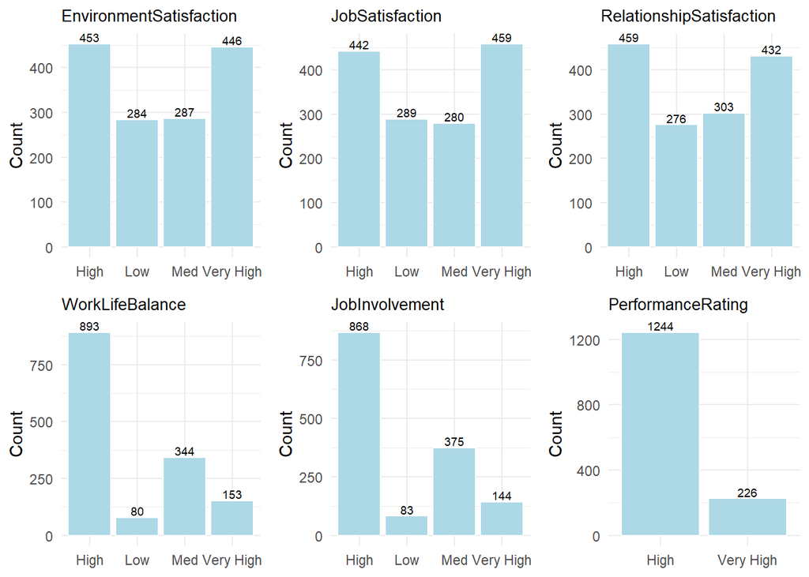

```r
#Attitudinal

#Plot Counts for High Level View
#Attitudinal: Environmental Satisfaction, Job Satisfaction, Relationship Satisfaction, WorkLifeBalance,Job Involvement, Performance Rating

EnvironSatPlot <- plotalldata %>%  group_by(EnvironmentSatisfaction) %>%  summarise(counts = n()) %>%
    ggplot(aes(x = as.factor(EnvironmentSatisfaction), y = counts)) +
    geom_bar(stat = 'identity', fill = "light blue",col = "white") +
    ggtitle("EnvironmentSatisfaction") + ylab("Count") + theme_minimal() +
    geom_text(aes(label=counts), size = 2.5, position=position_dodge(width=0.3), vjust=-0.25) +
  theme(plot.title = element_text(size =10),axis.title.x=element_blank())

JobSatPlot <- plotalldata %>%   group_by(JobSatisfaction) %>%  summarise(counts = n()) %>%
    ggplot(aes(x = as.factor(JobSatisfaction), y = counts)) +
    geom_bar(stat = 'identity', fill = "light blue",col = "white") +
    ggtitle("JobSatisfaction") + ylab("Count") + theme_minimal() +
    geom_text(aes(label=counts), size = 2.5, position=position_dodge(width=0.3), vjust=-0.25) +
  theme(plot.title = element_text(size =10),axis.title.x=element_blank())

RelatSatPlot <- plotalldata %>%  group_by(RelationshipSatisfaction) %>%  summarise(counts = n()) %>%
   ggplot(aes(x = as.factor(RelationshipSatisfaction), y = counts)) +
   geom_bar(stat = 'identity', fill = "light blue",col = "white") +
   ggtitle("RelationshipSatisfaction") + ylab("Count") + theme_minimal() +
   geom_text(aes(label=counts), size = 2.5, position=position_dodge(width=0.3), vjust=-0.25) +
  theme(plot.title = element_text(size =10),axis.title.x=element_blank())

WoLiBaPlot <- plotalldata %>%  group_by(WorkLifeBalance) %>%  summarise(counts = n()) %>%
    ggplot(aes(x = as.factor(WorkLifeBalance), y = counts)) +
    geom_bar(stat = 'identity', fill = "light blue",col = "white") +
    ggtitle("WorkLifeBalance") + ylab("Count") + theme_minimal() +
    geom_text(aes(label=counts), size = 2.5, position=position_dodge(width=0.3), vjust=-0.25) +
  theme(plot.title = element_text(size =10),axis.title.x=element_blank())

JobInvPlot <- plotalldata %>%   group_by(JobInvolvement) %>%  summarise(counts = n()) %>%
    ggplot(aes(x = as.factor(JobInvolvement), y = counts)) +
    geom_bar(stat = 'identity', fill = "light blue",col = "white") +
    ggtitle("JobInvolvement") + ylab("Count") + theme_minimal() +
    geom_text(aes(label=counts), size = 2.5, position=position_dodge(width=0.3), vjust=-0.25) +
  theme(plot.title = element_text(size =10),axis.title.x=element_blank())

PerfRatingPlot <- plotalldata %>%  group_by(PerformanceRating) %>%  summarise(counts = n()) %>%
    ggplot(aes(x = as.factor(PerformanceRating), y = counts)) +
    geom_bar(stat = 'identity', fill = "light blue",col = "white") +
    ggtitle("PerformanceRating") + ylab("Count") + theme_minimal() +
    geom_text(aes(label=counts), size = 2.5, position=position_dodge(width=0.3), vjust=-0.25) +
  theme(plot.title = element_text(size =10),axis.title.x=element_blank())

grid.arrange(EnvironSatPlot, JobSatPlot, RelatSatPlot, WoLiBaPlot, JobInvPlot, PerfRatingPlot, nrow = 2, ncol = 3)
```

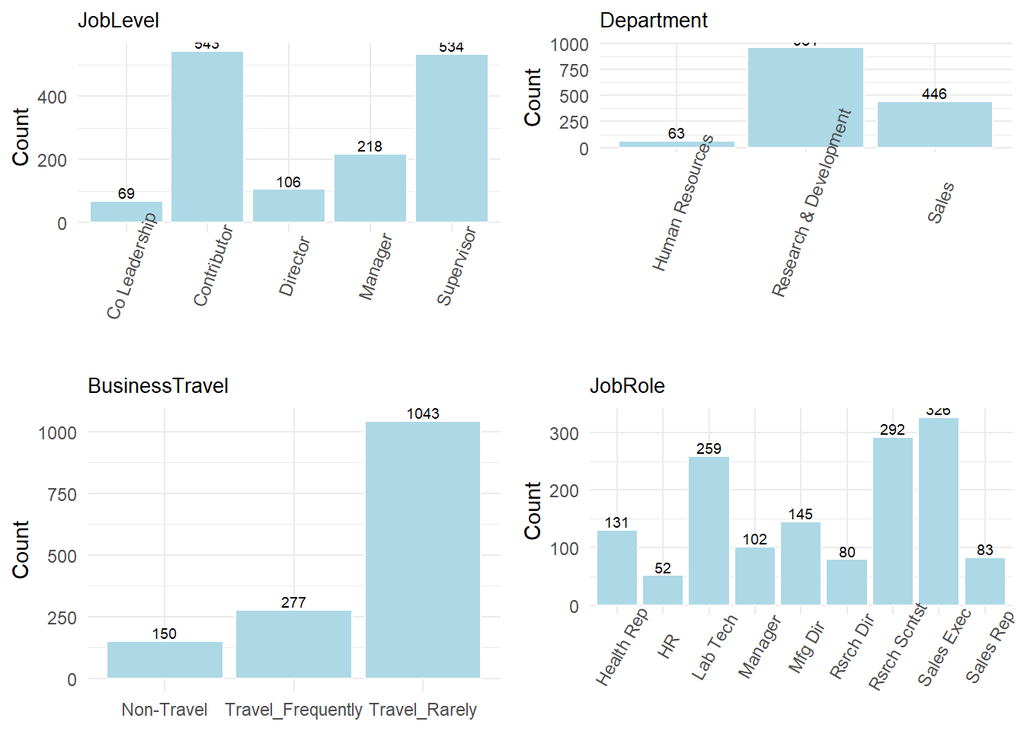

```r
#Plot Counts for High Level View
#Work Demographics: Job ROle, Job Level, Business Travel, Department, Training
#distribution of work demo details. Expect Right tail.

JobLevelPlot <- plotalldata %>%   group_by(JobLevel) %>%  summarise(counts = n()) %>%
    ggplot(aes(x = as.factor(JobLevel), y = counts)) +
    geom_bar(stat = 'identity', fill = "light blue",col = "white") +
    ggtitle("JobLevel") + ylab("Count") + theme_minimal() +
    geom_text(aes(label=counts), size = 2.5, position=position_dodge(width=0.3), vjust=-0.25) +
  theme(plot.title = element_text(size =10),axis.title.x=element_blank()) +
  theme(axis.text.x=element_text(angle=70,vjust=.8))

JobRolePlot <- plotalldata %>%   group_by(JobRole) %>%  summarise(counts = n()) %>%
    ggplot(aes(x = as.factor(JobRole), y = counts)) +
    geom_bar(stat = 'identity', fill = "light blue",col = "white") +
    ggtitle("JobRole") + ylab("Count") + theme_minimal() +
    geom_text(aes(label=counts), size = 2.5, position=position_dodge(width=0.3), vjust=-0.25) +
  theme(plot.title = element_text(size =10),axis.title.x=element_blank()) +
  theme(axis.text.x=element_text(angle=60,vjust=.8,hjust=.5))

BusinessTravelPlot <-  plotalldata %>%   group_by(BusinessTravel) %>%  summarise(counts = n()) %>%
    ggplot(aes(x = as.factor(BusinessTravel), y = counts)) +
    geom_bar(stat = 'identity', fill = "light blue",col = "white") +
    ggtitle("BusinessTravel") + ylab("Count") + theme_minimal() +
    geom_text(aes(label=counts), size = 2.5, position=position_dodge(width=0.3), vjust=-0.25) +
  theme(plot.title = element_text(size =10),axis.title.x=element_blank())

DepartmentPlot <-  plotalldata %>%   group_by(Department) %>%  summarise(counts = n()) %>%
    ggplot(aes(x = as.factor(Department), y = counts)) +
    geom_bar(stat = 'identity', fill = "light blue",col = "white") +
    ggtitle("Department") + ylab("Count") + theme_minimal() +
    geom_text(aes(label=counts), size = 2.5, position=position_dodge(width=0.3), vjust=-0.25) +
  theme(plot.title = element_text(size =10),axis.title.x=element_blank()) +
  theme(axis.text.x=element_text(angle=70,vjust=.8,hjust=.5))

TrainingPlot <-  plotalldata %>%   group_by(TrainingTimesLastYear) %>%  summarise(counts = n()) %>%
    ggplot(aes(x = as.factor(TrainingTimesLastYear), y = counts)) +
    geom_bar(stat = 'identity', fill = "light blue",col = "white") +
    ggtitle("TrainingTimesLastYear") + ylab("Count") + theme_minimal() +
    geom_text(aes(label=counts), size = 2.5, position=position_dodge(width=0.3), vjust=-0.25) +
  theme(plot.title = element_text(size =10),axis.title.x=element_blank())

YearsAtCompanyPlot <- ggplot(plotalldata) +
  geom_histogram(aes(YearsAtCompany), binwidth = 1, fill = "light blue",col = "white") +
  ggtitle("YearsAtCompany") + ylab("Count") + theme_minimal()+
  theme(plot.title = element_text(size =10),axis.title.x=element_blank())                           # add main & axis titles

YearsInCurrentRolePlot <- ggplot(plotalldata) +
  geom_histogram(aes(YearsInCurrentRole), binwidth = 1, fill = "light blue",col = "white") +
  ggtitle("YearsInCurrentRole") + ylab("Count") + theme_minimal() +                                 # add main & axis titles
  theme(plot.title = element_text(size =10),axis.title.x=element_blank())

YearsSinceLastPromotionPlot <- ggplot(plotalldata) +
  geom_histogram(aes(YearsSinceLastPromotion), binwidth = 1, fill = "light blue",col = "white") +
  ggtitle("YearsSinceLastPromotion")+ ylab("Count") + theme_minimal() +                             # add main & axis titles
  theme(plot.title = element_text(size =10),axis.title.x=element_blank())

YearsWithCurrManagerPlot<- ggplot(plotalldata) +
  geom_histogram(aes(YearsWithCurrManager), binwidth = 1, fill = "light blue",col = "white") +
  ggtitle("YearsWithCurrManager") + ylab("Count") + theme_minimal() +                               # add main & axis titles
  theme(plot.title = element_text(size =10),axis.title.x=element_blank())

grid.arrange(JobLevelPlot, DepartmentPlot, BusinessTravelPlot, JobRolePlot, nrow = 2, ncol = 2)
```

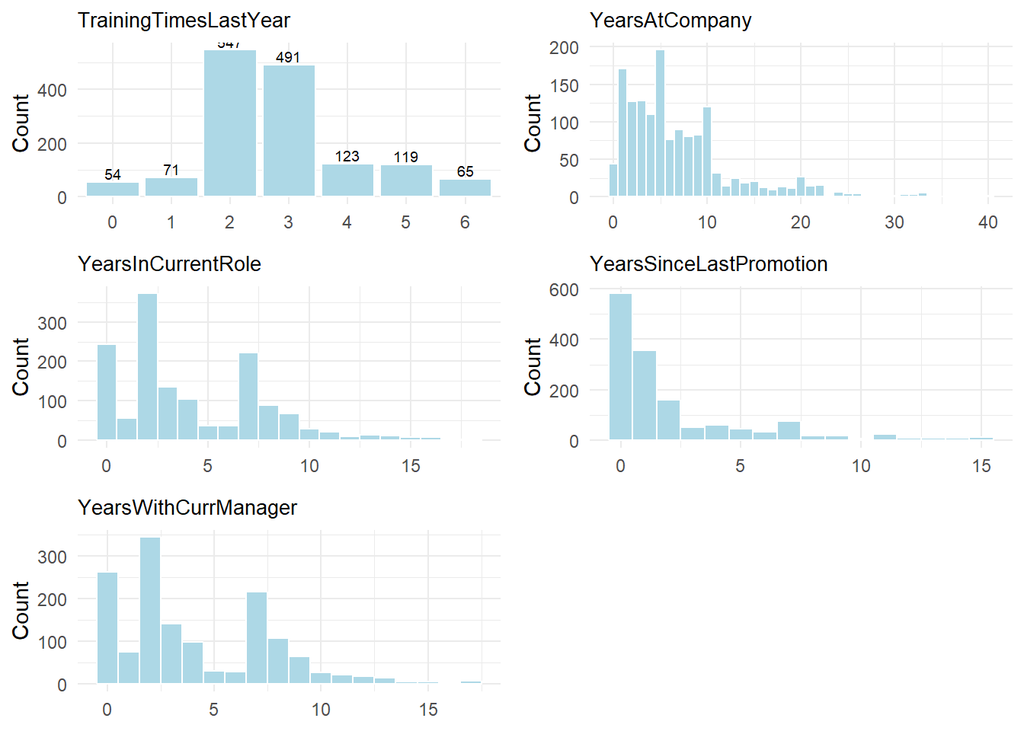

```r
grid.arrange(TrainingPlot, YearsAtCompanyPlot, YearsInCurrentRolePlot, YearsSinceLastPromotionPlot,YearsWithCurrManagerPlot,  nrow = 3, ncol = 2)
```

Financial Plots

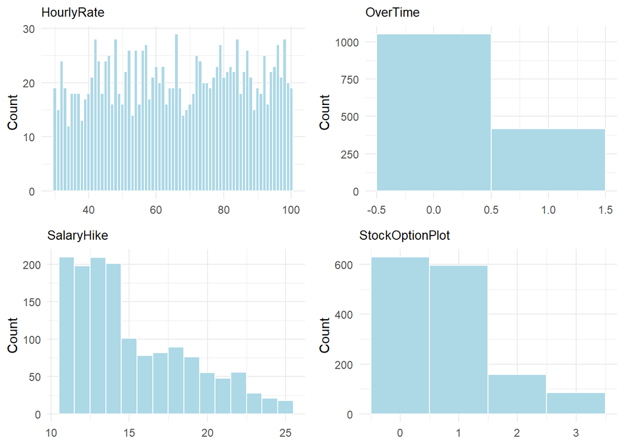

Demographic Attrition Plots

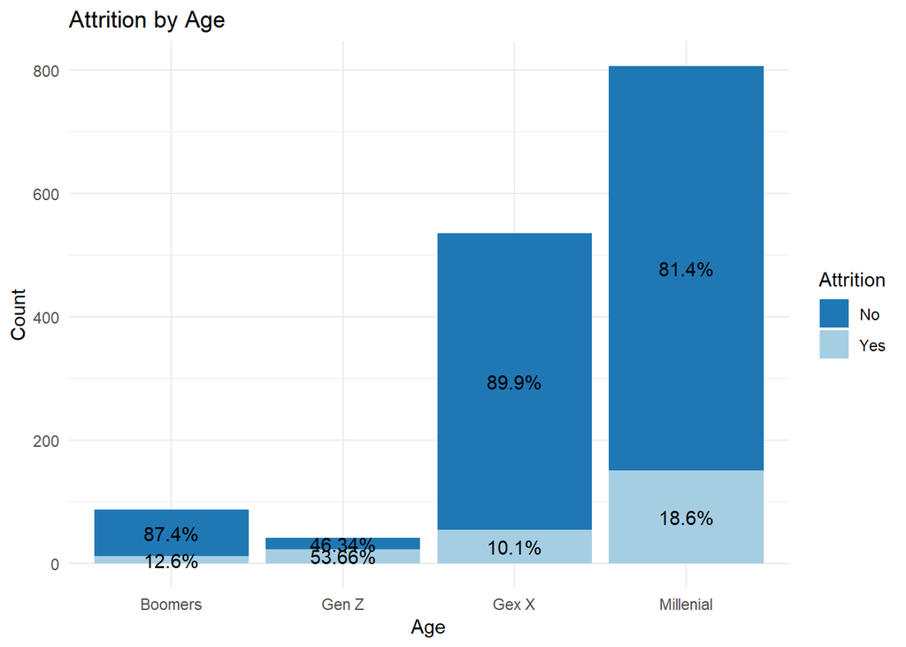

```r
# Attrition by Age
percentData <- plotalldata %>% group_by(Age) %>% count(Attrition) %>%
  mutate(ratio=scales::percent(n/sum(n)))
ggplot(plotalldata,aes(x=Age,fill=Attrition)) +
  ggtitle("Attrition by Age") + ylab("Count") +                                             # add main & axis titles
  scale_fill_brewer(palette="Paired",direction=-1)+ theme_minimal() +                       # change color palette
  geom_bar(aes(y = (..count..)),position=position_dodge()) +                                # side-by-side bars
  geom_bar(aes(y = (..count..))) +
  geom_text(data=percentData,aes(y=n,label=ratio),position=position_stack(vjust=.5))        # % labels
```

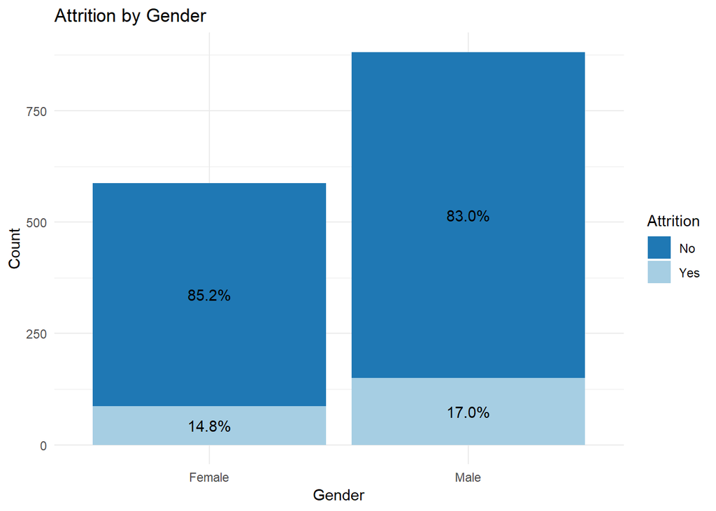

```r
# Attrition by Gender
percentData <- alldata %>% group_by(Gender) %>% count(Attrition) %>%
  mutate(ratio=scales::percent(n/sum(n)))
ggplot(alldata,aes(x=Gender,fill=Attrition)) +
  ggtitle("Attrition by Gender") + ylab("Count") +                                          # add main & axis titles
  scale_fill_brewer(palette="Paired",direction=-1)+ theme_minimal() +                       # change color palette
  geom_bar(aes(y = (..count..)),position=position_dodge()) +                                # side-by-side bars
  geom_bar(aes(y = (..count..))) +
  geom_text(data=percentData,aes(y=n,label=ratio),position=position_stack(vjust=.5))        # % labels
```

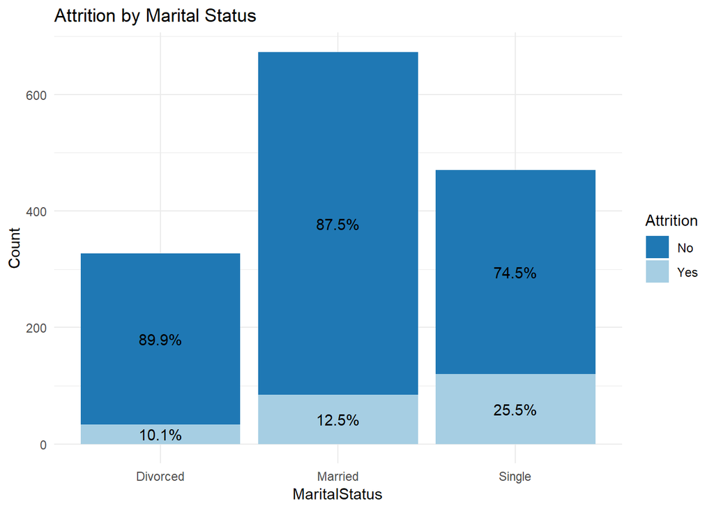

```r
# Attrition by Marital Status
percentData <- alldata %>% group_by(MaritalStatus) %>% count(Attrition) %>%
  mutate(ratio=scales::percent(n/sum(n)))
ggplot(alldata,aes(x=MaritalStatus,fill=Attrition)) +
  ggtitle("Attrition by Marital Status") + ylab("Count") +                                  # add main & axis titles
  scale_fill_brewer(palette="Paired",direction=-1)+ theme_minimal() +                       # change color palette
  geom_bar(aes(y = (..count..)),position=position_dodge()) +                                # side-by-side bars
  geom_bar(aes(y = (..count..))) +
  geom_text(data=percentData,aes(y=n,label=ratio),position=position_stack(vjust=.5))        # % labels
```

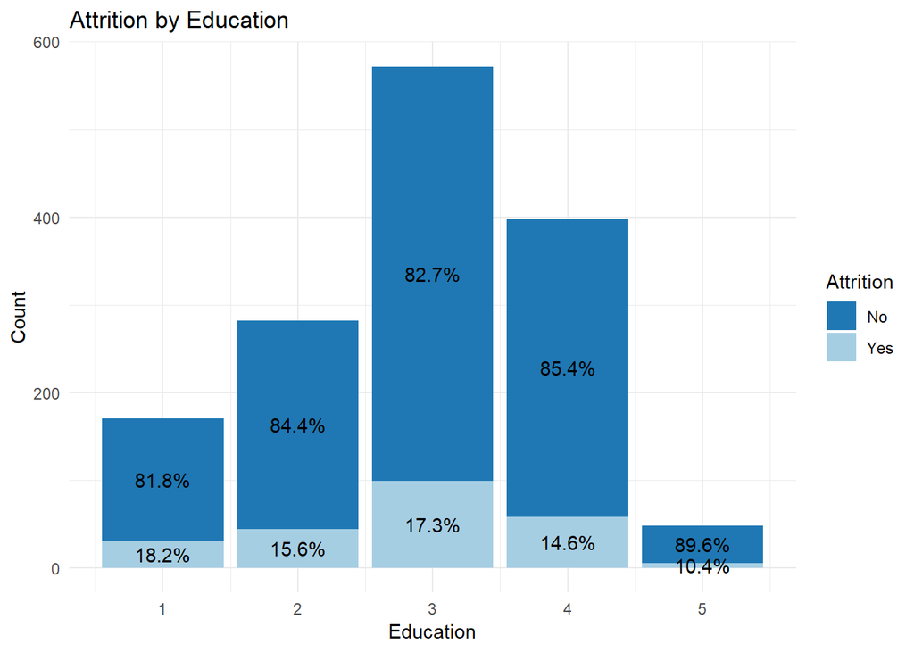

```r
# Attrition by Education
percentData <- alldata %>% group_by(Education) %>% count(Attrition) %>%
  mutate(ratio=scales::percent(n/sum(n)))
ggplot(alldata,aes(x=Education,fill=Attrition)) +
  ggtitle("Attrition by Education") + ylab("Count") +                                       # add main & axis titles
  scale_fill_brewer(palette="Paired",direction=-1)+ theme_minimal() +                       # change color palette
  geom_bar(aes(y = (..count..)),position=position_dodge()) +                                # side-by-side bars
  geom_bar(aes(y = (..count..))) +
  geom_text(data=percentData,aes(y=n,label=ratio),position=position_stack(vjust=.5))        # % labels
```

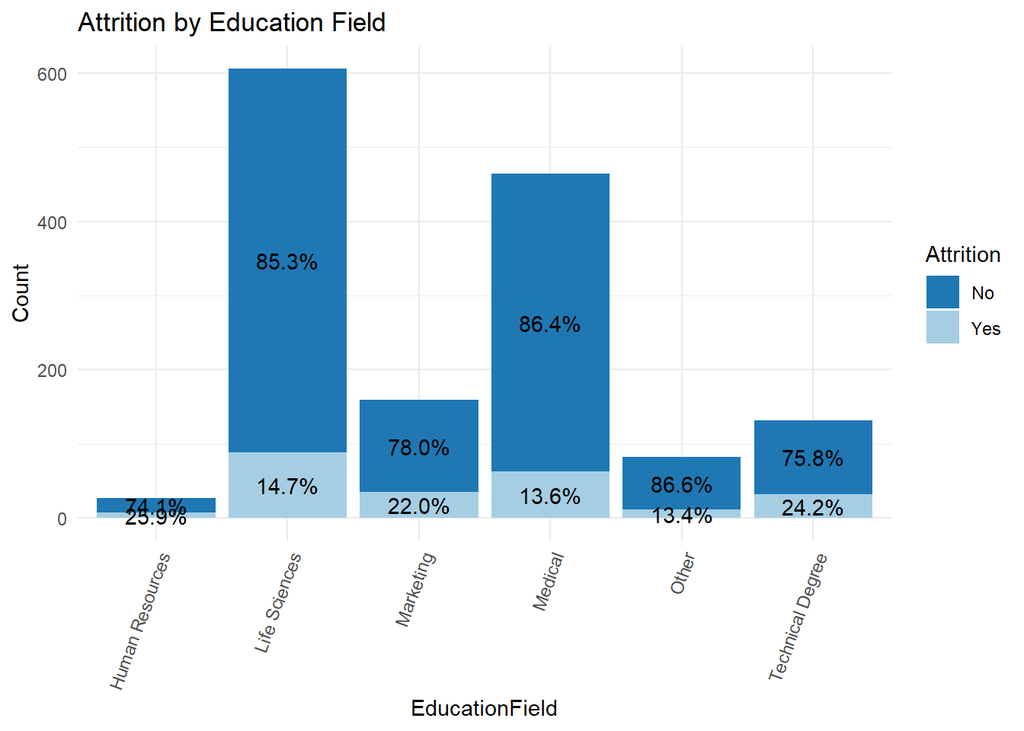

```r
# Attrition by Education Field
percentData <- alldata %>% group_by(EducationField) %>% count(Attrition) %>%
  mutate(ratio=scales::percent(n/sum(n)))
ggplot(alldata,aes(x=EducationField,fill=Attrition)) +
  ggtitle("Attrition by Education Field") + ylab("Count") +                                 # add main & axis titles
  scale_fill_brewer(palette="Paired",direction=-1)+ theme_minimal() +                       # change color palette
  geom_bar(aes(y = (..count..)),position=position_dodge()) +                                # side-by-side bars
  geom_bar(aes(y = (..count..))) +
  geom_text(data=percentData,aes(y=n,label=ratio),position=position_stack(vjust=.5)) +      # % labels
  theme(axis.text.x=element_text(angle=70,hjust=1))
```

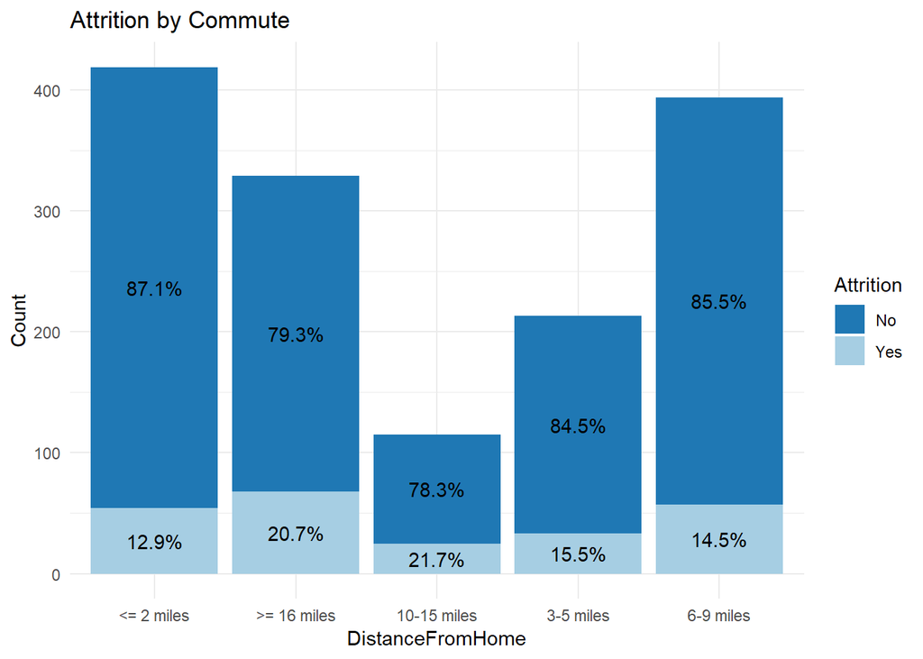

```r
# Attrition by Commute
percentData <- plotalldata %>% group_by(DistanceFromHome) %>% count(Attrition) %>%
  mutate(ratio=scales::percent(n/sum(n)))
ggplot(plotalldata,aes(x=DistanceFromHome,fill=Attrition)) +
  ggtitle("Attrition by Commute") + ylab("Count") +                                         # add main & axis titles
  scale_fill_brewer(palette="Paired",direction=-1)+ theme_minimal() +                       # change color palette
  geom_bar(aes(y = (..count..)),position=position_dodge()) +                                # side-by-side bars
  geom_bar(aes(y = (..count..))) +
  geom_text(data=percentData,aes(y=n,label=ratio),position=position_stack(vjust=.5))        # % labels
```

Attitudinal Attrition Plots

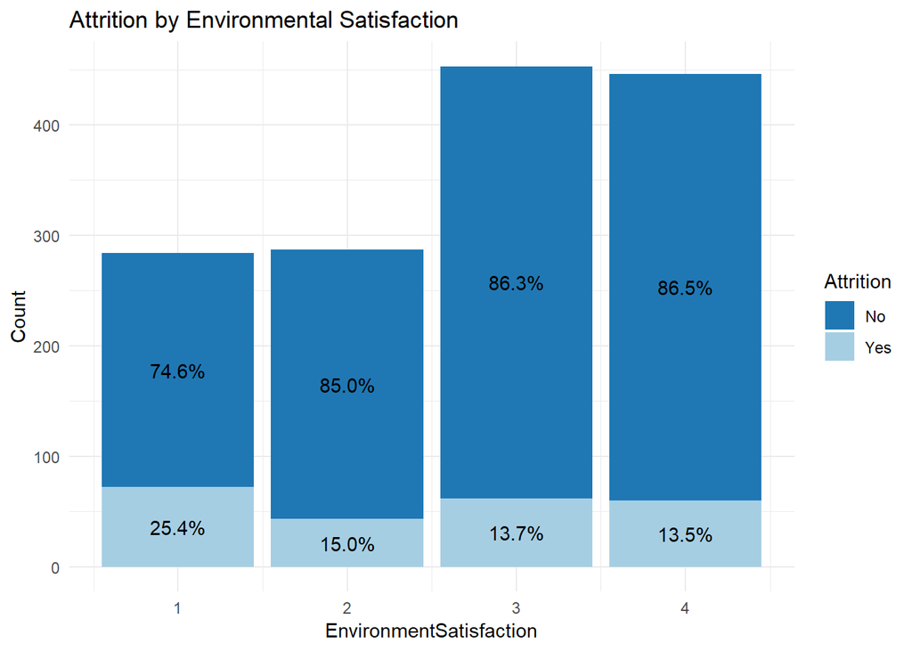

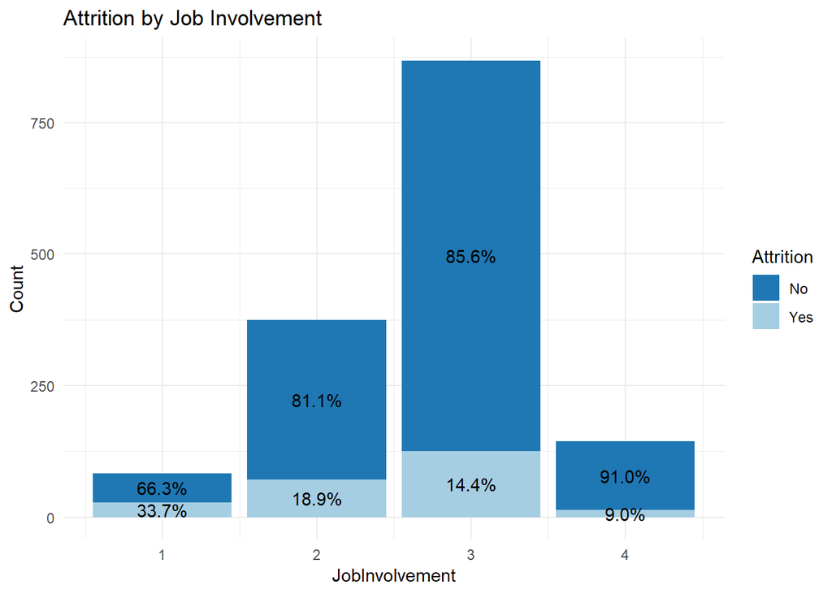

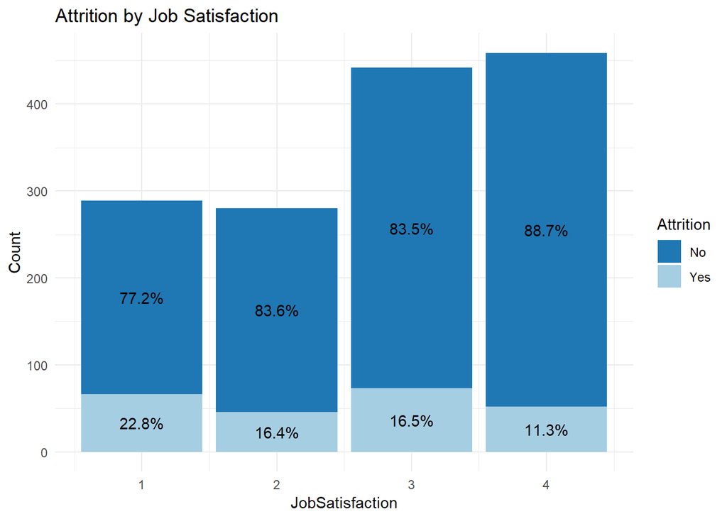

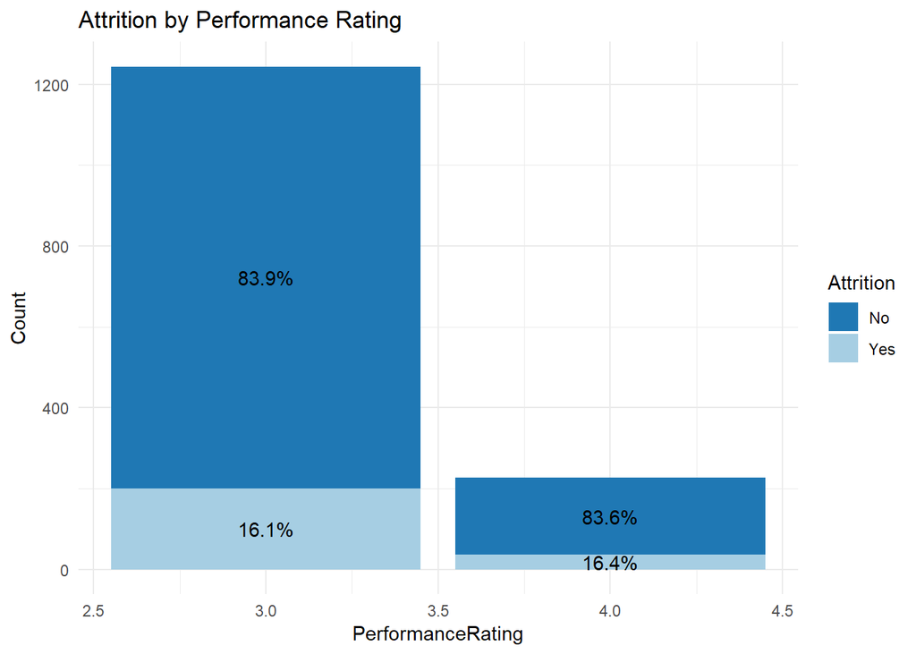

Work Attrition Plots

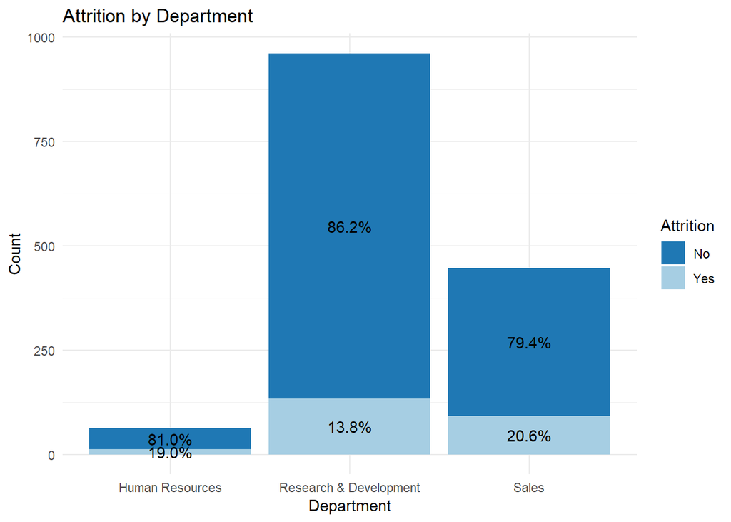

```r
par(mfrow=c(1,3))
# Attrition by Department
percentData <- alldata %>% group_by(Department) %>% count(Attrition) %>%
  mutate(ratio=scales::percent(n/sum(n)))
ggplot(alldata,aes(x=Department,fill=Attrition)) +
  ggtitle("Attrition by Department") + ylab("Count") +                                      # add main & axis titles
  scale_fill_brewer(palette="Paired",direction=-1)+ theme_minimal() +                       # change color palette
  geom_bar(aes(y = (..count..)),position=position_dodge()) +                                # side-by-side bars
  geom_bar(aes(y = (..count..))) +
  geom_text(data=percentData,aes(y=n,label=ratio),position=position_stack(vjust=.5))        # % labels
```

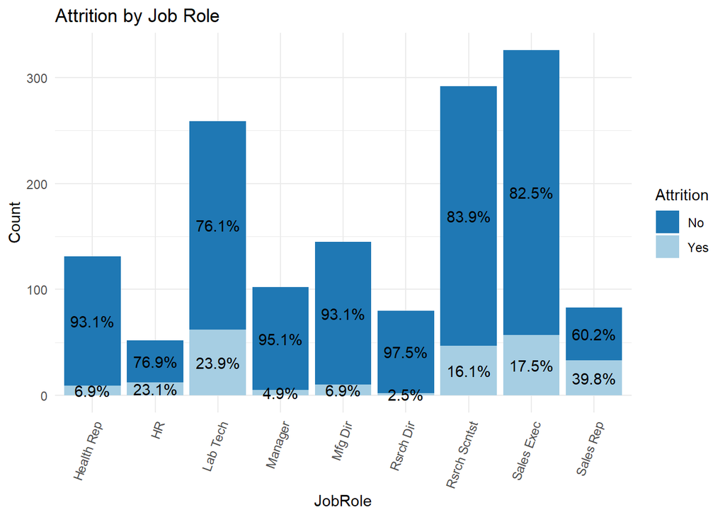

```r
# Attrition by Job Role
percentData <- alldata %>% group_by(JobRole) %>% count(Attrition) %>%
  mutate(ratio=scales::percent(n/sum(n)))
ggplot(alldata,aes(x=JobRole,fill=Attrition)) +
  ggtitle("Attrition by Job Role") + ylab("Count") +                                        # add main & axis titles
  scale_fill_brewer(palette="Paired",direction=-1)+ theme_minimal() +                       # change color palette
  geom_bar(aes(y = (..count..)),position=position_dodge()) +                                # side-by-side bars
  geom_bar(aes(y = (..count..))) +
  geom_text(data=percentData,aes(y=n,label=ratio),position=position_stack(vjust=.5)) +      # % labels
  theme(axis.text.x=element_text(angle=70,hjust=1))
```

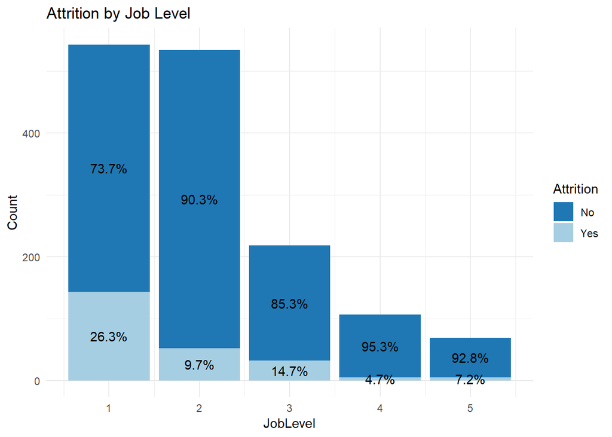

```r
# Attrition by Job Level
percentData <- alldata %>% group_by(JobLevel) %>% count(Attrition) %>%
  mutate(ratio=scales::percent(n/sum(n)))
ggplot(alldata,aes(x=JobLevel,fill=Attrition)) +
  ggtitle("Attrition by Job Level") + ylab("Count") +                                       # add main & axis titles
  scale_fill_brewer(palette="Paired",direction=-1)+ theme_minimal() +                       # change color palette
  geom_bar(aes(y = (..count..)),position=position_dodge()) +                                # side-by-side bars
  geom_bar(aes(y = (..count..))) +
  geom_text(data=percentData,aes(y=n,label=ratio),position=position_stack(vjust=.5))        # % labels
```

```r
# Attrition by Travel
percentData <- alldata %>% group_by(BusinessTravel) %>% count(Attrition) %>%
  mutate(ratio=scales::percent(n/sum(n)))
aTravel<-ggplot(alldata,aes(x=BusinessTravel,fill=Attrition)) +
  ggtitle("Attrition by Business Travel") + ylab("Count") +                                 # add main & axis titles
  scale_fill_brewer(palette="Paired",direction=-1)+ theme_minimal() +                       # change color palette
  geom_bar(aes(y = (..count..))) +
  geom_text(data=percentData,aes(y=n,label=ratio),position=position_stack(vjust=.5))        # % labels
```

Financial Attrition Plots

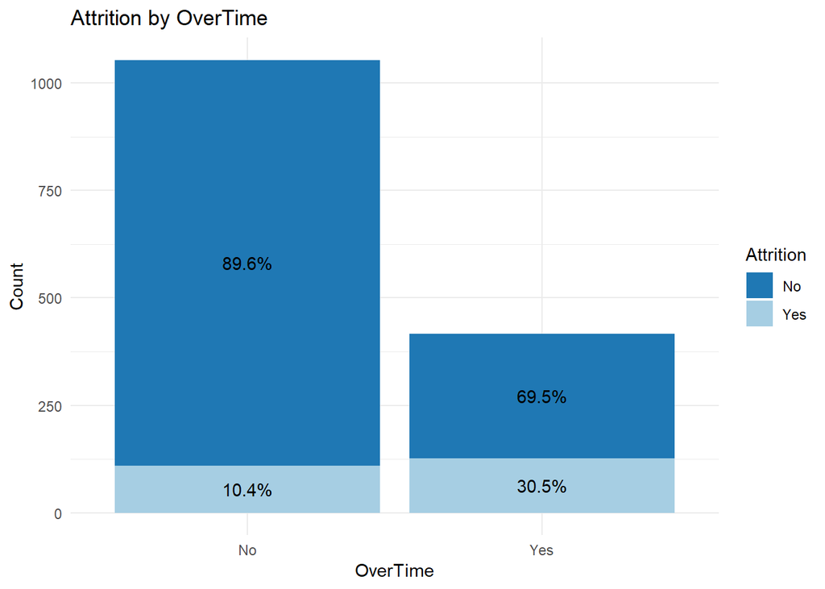

```r
# Attrition by Overtime
percentData <- alldata %>% group_by(OverTime) %>% count(Attrition) %>%
  mutate(ratio=scales::percent(n/sum(n)))
ggplot(alldata,aes(x=OverTime,fill=Attrition)) +
  ggtitle("Attrition by OverTime") + ylab("Count") +                                        # add main & axis titles
  scale_fill_brewer(palette="Paired",direction=-1)+ theme_minimal() +                       # change color palette
  geom_bar(aes(y = (..count..)),position=position_dodge()) +                                # side-by-side bars
  geom_bar(aes(y = (..count..))) +
  geom_text(data=percentData,aes(y=n,label=ratio),position=position_stack(vjust=.5))        # % labels
```

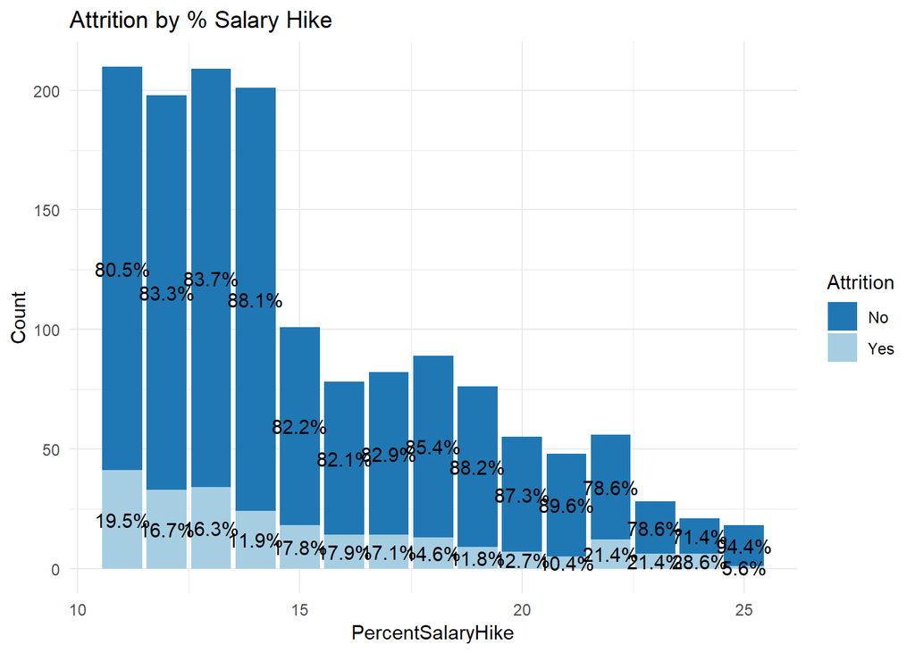

```r
# Attrition by Percent Salary Hike
percentData <- alldata %>% group_by(PercentSalaryHike) %>% count(Attrition) %>%
  mutate(ratio=scales::percent(n/sum(n)))
ggplot(alldata,aes(x=PercentSalaryHike,fill=Attrition)) +
  ggtitle("Attrition by % Salary Hike") + ylab("Count") +                                        # add main & axis titles
  scale_fill_brewer(palette="Paired",direction=-1)+ theme_minimal() +                       # change color palette
  geom_bar(aes(y = (..count..)),position=position_dodge()) +                                # side-by-side bars
  geom_bar(aes(y = (..count..))) +
  geom_text(data=percentData,aes(y=n,label=ratio),position=position_stack(vjust=.5))        # % labels
```

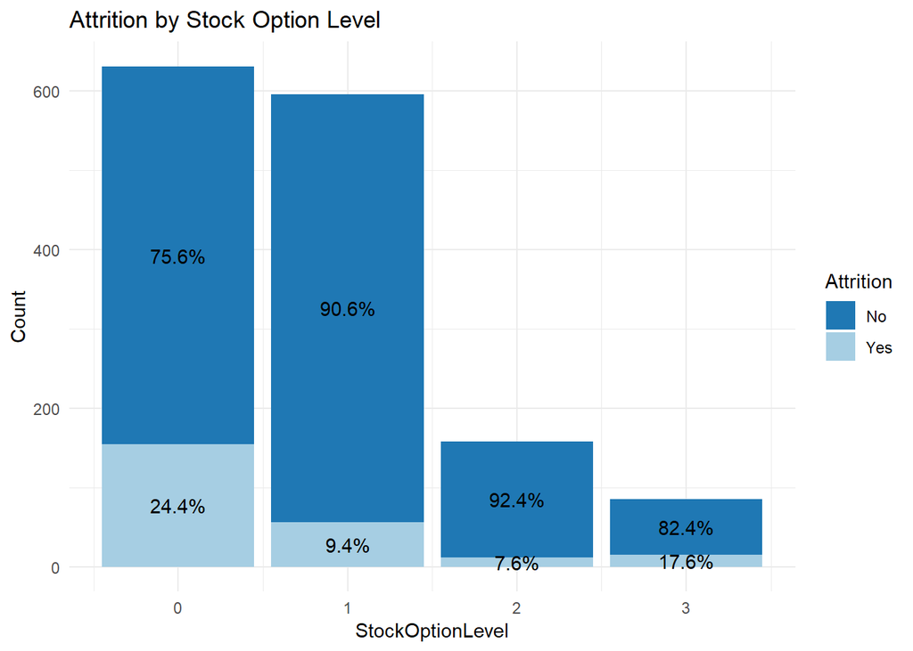

```r
# Attrition by Percent Salary Hike
percentData <- alldata %>% group_by(StockOptionLevel) %>% count(Attrition) %>%
  mutate(ratio=scales::percent(n/sum(n)))
ggplot(alldata,aes(x=StockOptionLevel,fill=Attrition)) +
  ggtitle("Attrition by Stock Option Level") + ylab("Count") +                                        # add main & axis titles
  scale_fill_brewer(palette="Paired",direction=-1)+ theme_minimal() +                       # change color palette
  geom_bar(aes(y = (..count..)),position=position_dodge()) +                                # side-by-side bars
  geom_bar(aes(y = (..count..))) +
  geom_text(data=percentData,aes(y=n,label=ratio),position=position_stack(vjust=.5))        # % labels
```

#### Feature Analysis

Correlation plots provide a quick way to identify correlation between variables. You want correlation with Attrition but you want to be careful about including variables that are collinear with each other since they can negatively affect the model. Selecting the optimal features requires an iteration between initial EDA, review of collinearity plots, variable inflation factors, variable p-values, model output.

Here we show collinearity plots. We recoded Attrition and used dummy variables for the categorical data and applied the corrplot function (since it uses only numerical data). In order to see the plots clearer, we split the data into 5 different different plots but keeping Attrition in each plot.

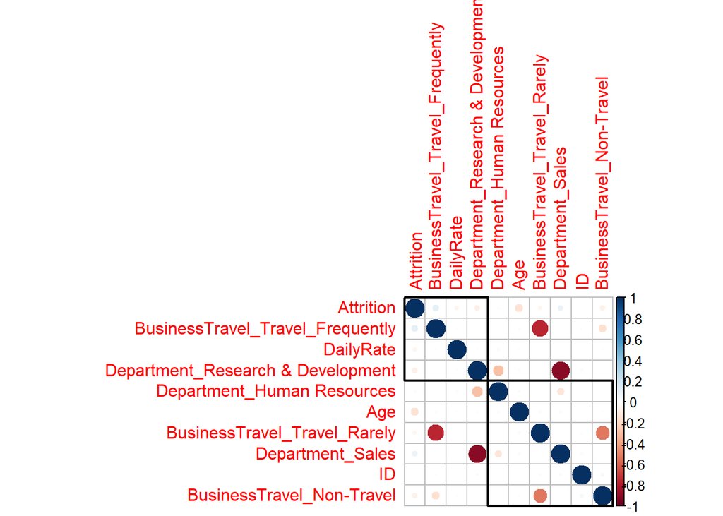

```r
# Split data to create 2 correlation matrices, more readable
data<-alldata[,-c(10,11,23,28,37)]                                                # remove EmpCount, Emp #, Over18, StdHrs,Rand
data$Attrition <- ifelse(data [,3] == "Yes", 1, ifelse(data[,3] == "No", 0, 99))  # Recode Attrition with 0s and 1s
data <- one_hot(as.data.table(data))                                              # Create dummy vars for categories

# Looking for linear relationships so will not normaalize
#data_n <- lapply(data,normalize)                                                 # normalize numeric data
#data <- data.frame(data_n)                                                       # create dataframe of normalized data

# create sets of data for corr plot viewing
data1<-data[,c(1:10)]
data2<-data[,c(1,3,11:20)]
data3<-data[,c(1,3,21:30)]
data4<-data[,c(1,3,31:41)]
data5<-data[,c(1,3,42:50)]

M_df1 <- select_if(data1, is.numeric)                                              # get all numeric data
M1 <- cor(M_df1)                                                                   # convert to matrix
corrplot(M1, order="hclust",addrect=2)                                             # Display the correlation coefficient
```

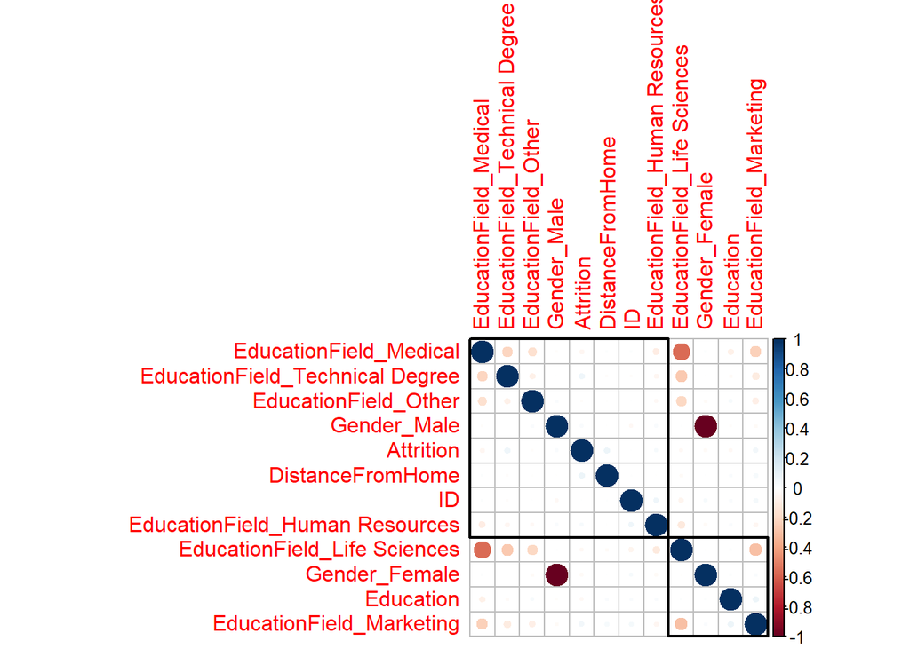

```r
M_df2 <- select_if(data2, is.numeric)                                              # get all numeric data
M2 <- cor(M_df2)                                                                   # convert to matrix
corrplot(M2, order="hclust",addrect=2)                                             # Display the correlation coefficient
```

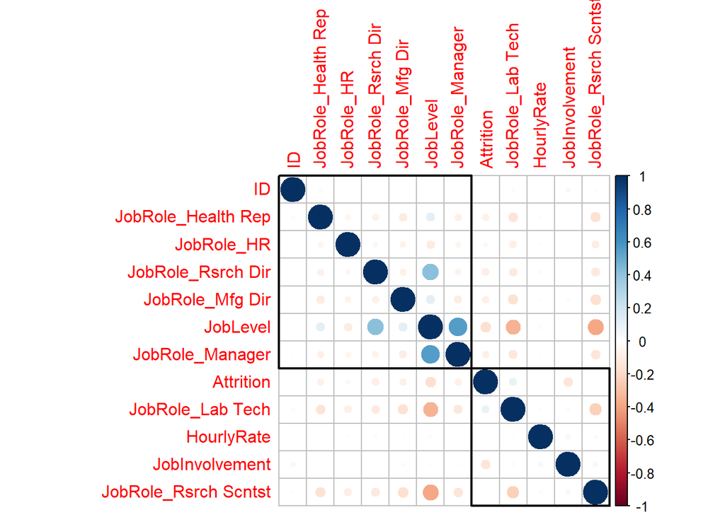

```r
M_df3 <- select_if(data3, is.numeric)                                              # get all numeric data
M3 <- cor(M_df3)                                                                   # convert to matrix
corrplot(M3, order="hclust",addrect=2)                                             # Display the correlation coefficient
```

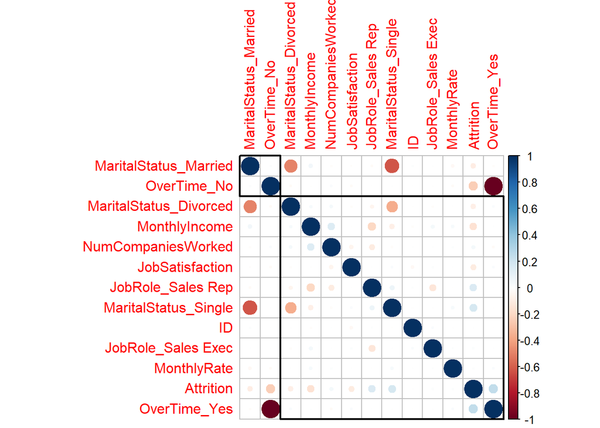

```r
M_df4 <- select_if(data4, is.numeric)                                              # get all numeric data
M4 <- cor(M_df4)                                                                   # convert to matrix
corrplot(M4, order="hclust",addrect=2)                                             # Display the correlation coefficient
```

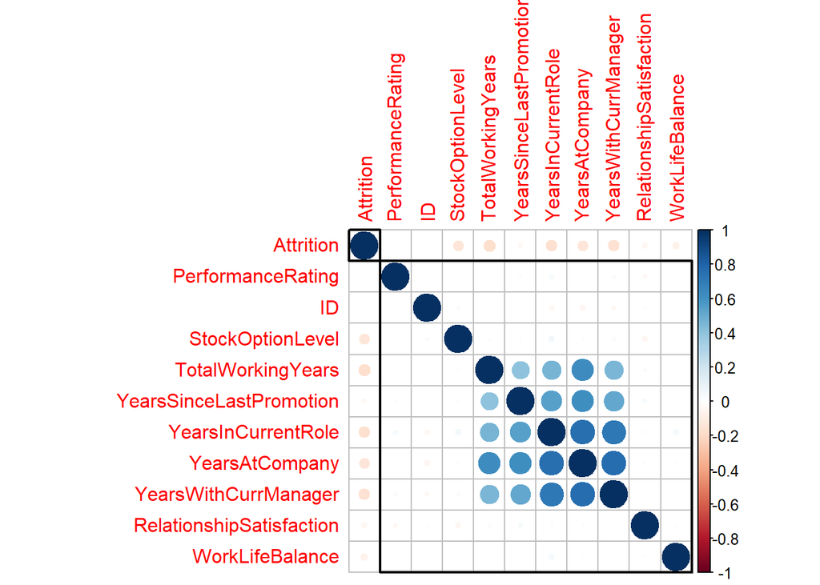

```r
M_df5 <- select_if(data5, is.numeric)                                              # get all numeric data
M5 <- cor(M_df5)                                                                   # convert to matrix
corrplot(M5, order="hclust",addrect=2)                                             # Display the correlation coefficient
```